# (Ford GoBike Presentation )

## by (Buthaina Alotaibi)

## Investigation Overview

> The main goal for this presentation is to present interesting patterns and relationships between different features that are discovered throughout the analysis.

## Dataset Overview

> The dataset for Ford GoBike aggregates the data for rides in February 2019, Ford GoBike is the Bay Area’s bike share system. Bay Area Bike Share was introduced in 2013. It services San Francisco, the East Bay and San Jose. It contains 183412 row and 16 columns.

## (Frequency by weekdays)

> The plot shows the distribution between weekdays. The distribution between weekdays shows that Thursday and Tuesday are the peak days and most of the rides are during these days, on the other hand Sunday and Saturday are the least days. We can conclude from this information that most of the members are using it for work so there’s no need to use it on the weekends.

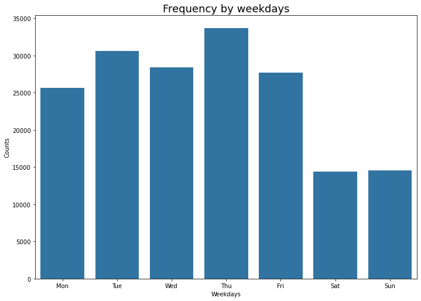

## (Durations of rides for age groups)

> This plot shows the duration of rides for each age group. The age group 30-40 tends to have more duration for riders.

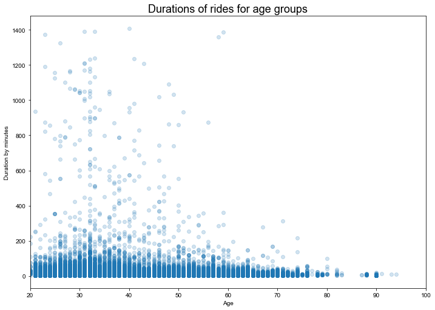

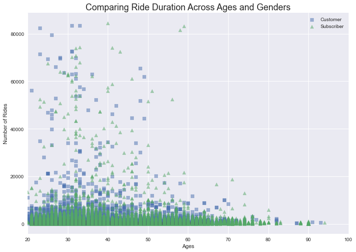